# RestoreDART pooled model results

BEM

October 2026

## Notes

- This document reports the **pooled mixed models**: one model per objective x cover response, fit to the pixel-level DART effects that the three `2_*.Rmd` documents summarise descriptively. Those documents count and average significant pixels; this one asks what the effect was as a function of time since treatment, treatment type, climate, ecoregion and pre-treatment cover, with polygons and pixels as random groupings. Read `2_make_DART_results.Rmd` first: the sample these models are fit to is the one its filtering log describes.
- Nothing here fits a model. `3_make_linear_models.R` does the fitting and writes a dated run directory of `.csv` tables, `.png` figures and one `.Rdata` of plot objects; this document loads that directory and displays it. A re-render costs seconds and cannot change a result.
- **Which run is shown is a property of the directory, not of this document.** The run manifest is the first table below and records the pixels used, the sample-size thresholds in force and the package versions. Point the document at a different run by editing `run_dir` in the setup chunk.
- The document runs in this order: the run’s own settings and sample, then model selection, then what the selected models say - variance first, fixed effects second - then the fit diagnostics, and last the caveats. Diagnostics sit near the end because they qualify everything above them rather than belonging to any one section.

## The run

These results come from `RestoreDART_model_run_10072026`, fit on 2026-10-07 with all post-filter pixels, covering 5 objective x cover response combinations.

The distinction the `pixels_used` field records is the single most important thing to settle before reading anything below, because the two settings estimate different quantities rather than the same quantity two ways. Fitting **all post-filter pixels** estimates the average treatment effect across the treated landscape, counting the pixels where DART detected nothing as the near-zero estimates they are - this is what a reader assumes when a paper reports “the effect of seeding”. Fitting **significant pixels only** estimates the average effect among detected effects, which is the quantity the three `2_*.Rmd` documents report throughout, and so is the setting whose magnitudes are comparable with them. A difference between the two runs is not a disagreement to be resolved.

Run manifest: the settings under which these models were fit. `min_txeco_n` and `min_year_n` are the sample-size thresholds inherited from 2_results_setup.R, listed as the keyed vectors they are set as; `n_poly_sub` records whether the fit used every polygon or a subsample.

| Setting | Value |
| --- | --- |
| run_date | 2026-10-07 |
| run_tag | allpix |
| sig_only | FALSE |
| pixels_used | all post-filter pixels |
| n_poly_sub | all polygons |
| n_objectives | 5 |
| n_models | 7 |
| random_slope | FALSE |
| ci_method | Wald |
| n_ppd | 200 |
| n_singular | 0 |
| n_conv_warning | 0 |
| scaled_covs | aridity, spei, mean_cover_5YBT |
| min_txeco_n | default=10; decrease_afg_AFG=300; increase_pfg_PFG=300; increase_shr_SHR=300; decrease_shr_SHR=300 |
| drop_depopulated | TRUE |
| min_year_n | default=10 |
| year_trunc_metric | significant |
| input_file | 1_combined_filter_input_data_10072026.csv |
| r_version | 4.5.3 |
| lme4_version | 2.0.6 |

## The sample each model was fit to

`n_pix_avail` is the objective’s post-filter pixel count - after the sparse treatment x ecoregion cells, any depopulated levels and the late-year truncation, all at this run’s thresholds. `n_row` is what reached `lmer()` after dropping rows with a missing covariate and, in a `sigonly` run, after the significance subset. The gap between them is worth reading: a covariate that is largely missing for one objective shows up here and nowhere else.

Rows, polygons and factor levels entering each objective’s models. `# Models` is the number of rungs of the ladder that were estimable for that objective: a specification is skipped when the factor it adds has fewer than two surviving levels.

| Objective | Cover | Significant Only | Pixels Available | Rows Fit | % Pixels Used | # Polygons | # Pixels | # Treatments | # Ecoregions | # Models |
| --- | --- | --- | --- | --- | --- | --- | --- | --- | --- | --- |
| decrease_afg | AFG | FALSE | 84175 | 84175 | 100 | 104 | 623 | 6 | 14 | 7 |
| increase_pfg | PFG | FALSE | 605946 | 605946 | 100 | 539 | 4548 | 12 | 22 | 7 |
| increase_shr | SHR | FALSE | 285880 | 285880 | 100 | 386 | 939 | 12 | 19 | 7 |
| decrease_shr | SHR | FALSE | 186596 | 186596 | 100 | 61 | 4560 | 11 | 8 | 7 |
| decrease_tre | TRE | FALSE | 556499 | 556499 | 100 | 453 | 4557 | 13 | 15 | 7 |

## Model comparison

Seven nested specifications per objective, fit by maximum likelihood (`REML = FALSE`, which is what makes likelihoods comparable across different fixed-effect structures). `m0` has no fixed effects and exists to partition the variance; each later rung adds one term - time since treatment, treatment type, aridity, SPEI, ecoregion, pre-treatment cover - in the order of KY’s original ladder.

**`delta_aic` is within an objective, not across objectives.** Each objective’s models are fit to a different number of rows, so an AIC from `decrease_tre` and one from `increase_pfg` are not on the same scale. Two further cautions: the ladder is strictly nested, so AIC rewards the larger model whenever the added covariate does anything at all, and a `delta_aic` of one or two between adjacent rungs is not a reason to prefer either.

Model comparison within each objective. The selected model in every section below is the lowest-AIC rung, i.e. the row where delta AIC is 0.

| Objective | Cover | Model | Rows Fit | df | log-Likelihood | AIC | delta AIC |
| --- | --- | --- | --- | --- | --- | --- | --- |
| decrease_afg | AFG | m0 | 84175 | 4 | -305716.1 | 611440.1 | 1045.72 |
| decrease_afg | AFG | m1 | 84175 | 5 | -305689.8 | 611389.5 | 995.12 |
| decrease_afg | AFG | m2 | 84175 | 10 | -305686.0 | 611392.1 | 997.65 |
| decrease_afg | AFG | m3 | 84175 | 11 | -305681.9 | 611385.9 | 991.44 |
| decrease_afg | AFG | m4 | 84175 | 12 | -305628.5 | 611281.1 | 886.67 |
| decrease_afg | AFG | m5 | 84175 | 25 | -305615.8 | 611281.6 | 887.18 |
| decrease_afg | AFG | m6 | 84175 | 26 | -305171.2 | 610394.4 | 0.00 |
| increase_pfg | PFG | m0 | 605946 | 4 | -1871388.8 | 3742785.6 | 23940.19 |
| increase_pfg | PFG | m1 | 605946 | 5 | -1870183.4 | 3740376.9 | 21531.49 |
| increase_pfg | PFG | m2 | 605946 | 16 | -1870147.4 | 3740326.8 | 21481.43 |
| increase_pfg | PFG | m3 | 605946 | 17 | -1868692.1 | 3737418.3 | 18572.89 |
| increase_pfg | PFG | m4 | 605946 | 18 | -1860433.4 | 3720902.8 | 2057.40 |
| increase_pfg | PFG | m5 | 605946 | 39 | -1860403.0 | 3720883.9 | 2038.53 |
| increase_pfg | PFG | m6 | 605946 | 40 | -1859382.7 | 3718845.4 | 0.00 |
| increase_shr | SHR | m0 | 285880 | 4 | -827992.2 | 1655992.4 | 8310.61 |
| increase_shr | SHR | m1 | 285880 | 5 | -827221.4 | 1654452.9 | 6771.06 |
| increase_shr | SHR | m2 | 285880 | 16 | -827208.7 | 1654449.3 | 6767.49 |
| increase_shr | SHR | m3 | 285880 | 17 | -827154.0 | 1654342.0 | 6660.24 |
| increase_shr | SHR | m4 | 285880 | 18 | -826145.2 | 1652326.3 | 4644.53 |
| increase_shr | SHR | m5 | 285880 | 36 | -826124.8 | 1652321.6 | 4639.79 |
| increase_shr | SHR | m6 | 285880 | 37 | -823803.9 | 1647681.8 | 0.00 |
| decrease_shr | SHR | m0 | 186596 | 4 | -583226.0 | 1166460.0 | 5362.64 |
| decrease_shr | SHR | m1 | 186596 | 5 | -583038.6 | 1166087.1 | 4989.77 |
| decrease_shr | SHR | m2 | 186596 | 15 | -583030.2 | 1166090.5 | 4993.18 |
| decrease_shr | SHR | m3 | 186596 | 16 | -582436.4 | 1164904.9 | 3807.52 |
| decrease_shr | SHR | m4 | 186596 | 17 | -581677.4 | 1163388.8 | 2291.44 |
| decrease_shr | SHR | m5 | 186596 | 24 | -581675.7 | 1163399.4 | 2302.06 |
| decrease_shr | SHR | m6 | 186596 | 25 | -580523.7 | 1161097.3 | 0.00 |
| decrease_tre | TRE | m0 | 556499 | 4 | -1644842.9 | 3289693.8 | 21179.90 |
| decrease_tre | TRE | m1 | 556499 | 5 | -1637043.0 | 3274096.0 | 5582.05 |
| decrease_tre | TRE | m2 | 556499 | 17 | -1636992.8 | 3274019.5 | 5505.60 |
| decrease_tre | TRE | m3 | 556499 | 18 | -1636935.2 | 3273906.4 | 5392.53 |
| decrease_tre | TRE | m4 | 556499 | 19 | -1636848.2 | 3273734.3 | 5220.44 |
| decrease_tre | TRE | m5 | 556499 | 33 | -1636833.7 | 3273733.4 | 5219.50 |
| decrease_tre | TRE | m6 | 556499 | 34 | -1634222.9 | 3268513.9 | 0.00 |

### Likelihood ratio tests

AIC ranks the rungs; this tests them. lme4 reports no p values on its fixed effects by design — the null distributions of those statistics are not t or F distributed at finite sample size, and the usual degrees-of-freedom corrections are approximations with no exact justification. The package’s own recommendation, when an inferential statement is needed, is to frame it as a likelihood ratio test by comparing nested models, which is what the ladder supports and what the table below reports. No refitting was involved: every rung was fit by maximum likelihood precisely so these likelihoods are comparable.

Each row tests one rung against the rung below it, so these are a sequence of nested comparisons rather than independent tests, and nothing here corrects for the several comparisons made within an objective. A term that improves the likelihood significantly at 605,946 rows can still be too small to matter.

Likelihood ratio tests along each objective’s ladder. Each row compares that rung against the one above it in the table; the first rung of each objective has no comparison and so no test statistic.

| Objective | Cover | Model | npar | Deviance | Chi-squared | df | p |
| --- | --- | --- | --- | --- | --- | --- | --- |
| decrease_afg | AFG | m0 | 4 | 611432.1 | NA | NA | NA |
| decrease_afg | AFG | m1 | 5 | 611379.5 | 52.602 | 1 | 0.000 |
| decrease_afg | AFG | m2 | 10 | 611372.1 | 7.467 | 5 | 0.188 |
| decrease_afg | AFG | m3 | 11 | 611363.9 | 8.207 | 1 | 0.004 |
| decrease_afg | AFG | m4 | 12 | 611257.1 | 106.778 | 1 | 0.000 |
| decrease_afg | AFG | m5 | 25 | 611231.6 | 25.484 | 13 | 0.020 |
| decrease_afg | AFG | m6 | 26 | 610342.4 | 889.183 | 1 | 0.000 |
| increase_pfg | PFG | m0 | 4 | 3742777.6 | NA | NA | NA |
| increase_pfg | PFG | m1 | 5 | 3740366.9 | 2410.696 | 1 | 0.000 |
| increase_pfg | PFG | m2 | 16 | 3740294.8 | 72.063 | 11 | 0.000 |
| increase_pfg | PFG | m3 | 17 | 3737384.3 | 2910.539 | 1 | 0.000 |
| increase_pfg | PFG | m4 | 18 | 3720866.8 | 16517.490 | 1 | 0.000 |
| increase_pfg | PFG | m5 | 39 | 3720805.9 | 60.864 | 21 | 0.000 |
| increase_pfg | PFG | m6 | 40 | 3718765.4 | 2040.533 | 1 | 0.000 |
| increase_shr | SHR | m0 | 4 | 1655984.4 | NA | NA | NA |
| increase_shr | SHR | m1 | 5 | 1654442.9 | 1541.552 | 1 | 0.000 |
| increase_shr | SHR | m2 | 16 | 1654417.3 | 25.568 | 11 | 0.008 |
| increase_shr | SHR | m3 | 17 | 1654308.0 | 109.257 | 1 | 0.000 |
| increase_shr | SHR | m4 | 18 | 1652290.3 | 2017.712 | 1 | 0.000 |
| increase_shr | SHR | m5 | 36 | 1652249.6 | 40.732 | 18 | 0.002 |
| increase_shr | SHR | m6 | 37 | 1647607.8 | 4641.794 | 1 | 0.000 |
| decrease_shr | SHR | m0 | 4 | 1166452.0 | NA | NA | NA |
| decrease_shr | SHR | m1 | 5 | 1166077.1 | 374.867 | 1 | 0.000 |
| decrease_shr | SHR | m2 | 15 | 1166060.5 | 16.591 | 10 | 0.084 |
| decrease_shr | SHR | m3 | 16 | 1164872.9 | 1187.653 | 1 | 0.000 |
| decrease_shr | SHR | m4 | 17 | 1163354.8 | 1518.081 | 1 | 0.000 |
| decrease_shr | SHR | m5 | 24 | 1163351.4 | 3.384 | 7 | 0.847 |
| decrease_shr | SHR | m6 | 25 | 1161047.3 | 2304.058 | 1 | 0.000 |
| decrease_tre | TRE | m0 | 4 | 3289685.8 | NA | NA | NA |
| decrease_tre | TRE | m1 | 5 | 3274086.0 | 15599.848 | 1 | 0.000 |
| decrease_tre | TRE | m2 | 17 | 3273985.5 | 100.453 | 12 | 0.000 |
| decrease_tre | TRE | m3 | 18 | 3273870.4 | 115.061 | 1 | 0.000 |
| decrease_tre | TRE | m4 | 19 | 3273696.3 | 174.098 | 1 | 0.000 |
| decrease_tre | TRE | m5 | 33 | 3273667.4 | 28.932 | 14 | 0.011 |
| decrease_tre | TRE | m6 | 34 | 3268445.9 | 5221.505 | 1 | 0.000 |

### Convergence and singular fits

Two different things, which mean different things. A **singular** fit is one where some variance component is estimated as exactly zero — the fit sits on the boundary of the parameter space. lme4 is deliberately built to represent that rather than fail on it, so a singular fit is a statement about the data, not a numerical problem: it usually means the grouping factor it names explains no variance once the others are in. With a pixel random intercept on data where many pixels are observed in only one or two years, a singular pixel term is a real possibility.

A **convergence warning** is the optimizer’s own complaint and deserves more attention, because the usual cause has already been ruled out: the package’s authors report seeing the underlying algorithm fail mainly on badly scaled predictors, and the three continuous covariates here were centred and scaled before fitting for exactly that reason.

This run has 0 singular fits and 0 fits carrying a convergence warning, out of 35 fitted models.

Every fit that is singular or carries a convergence warning. An empty table means every model in this run converged cleanly with no variance component on the boundary.

| Objective | Cover | Model | Singular | # Warnings | Optimizer | Message |
| --- | --- | --- | --- | --- | --- | --- |

### Sequential decomposition of the selected model

Sums of squares and F statistics for the fixed-effects terms of each objective’s selected model, in the order they enter the formula. **This is an informal reading, not a test.** There are no p values attached because there is no agreed way to obtain denominator degrees of freedom for these statistics — which is the same reason the coefficient table carries no p values. What the table supports is a comparison of relative magnitude: which terms account for much of what the model explains, and which for almost none.

Sequential means order-dependent. Each term is adjusted for the terms before it and not for those after, so `year_diff` — first in every formula — carries any variation it shares with the covariates that follow it.

Sequential (Type I) decomposition of each selected model’s fixed effects. F statistics are reported without p values, deliberately.

| Objective | Cover | Model | Term | npar | Sum Sq | Mean Sq | F |
| --- | --- | --- | --- | --- | --- | --- | --- |
| decrease_afg | AFG | m6 | year_diff | 1 | 3767.756 | 3767.756 | 52.639 |
| decrease_afg | AFG | m6 | tx_coarse | 5 | 615.272 | 123.054 | 1.719 |
| decrease_afg | AFG | m6 | aridity | 1 | 586.352 | 586.352 | 8.192 |
| decrease_afg | AFG | m6 | spei | 1 | 7641.380 | 7641.380 | 106.757 |
| decrease_afg | AFG | m6 | us_l4name | 13 | 1808.514 | 139.116 | 1.944 |
| decrease_afg | AFG | m6 | mean_cover_5YBT | 1 | 67732.018 | 67732.018 | 946.281 |
| increase_pfg | PFG | m6 | year_diff | 1 | 57906.103 | 57906.103 | 2502.876 |
| increase_pfg | PFG | m6 | tx_coarse | 11 | 2292.677 | 208.425 | 9.009 |
| increase_pfg | PFG | m6 | aridity | 1 | 69537.374 | 69537.374 | 3005.615 |
| increase_pfg | PFG | m6 | spei | 1 | 387734.918 | 387734.918 | 16759.073 |
| increase_pfg | PFG | m6 | us_l4name | 21 | 1740.126 | 82.863 | 3.582 |
| increase_pfg | PFG | m6 | mean_cover_5YBT | 1 | 48481.741 | 48481.741 | 2095.527 |
| increase_shr | SHR | m6 | year_diff | 1 | 24153.362 | 24153.362 | 1559.087 |
| increase_shr | SHR | m6 | tx_coarse | 11 | 705.513 | 64.138 | 4.140 |
| increase_shr | SHR | m6 | aridity | 1 | 1711.014 | 1711.014 | 110.445 |
| increase_shr | SHR | m6 | spei | 1 | 31385.123 | 31385.123 | 2025.893 |
| increase_shr | SHR | m6 | us_l4name | 18 | 1052.878 | 58.493 | 3.776 |
| increase_shr | SHR | m6 | mean_cover_5YBT | 1 | 79462.605 | 79462.605 | 5129.269 |
| decrease_shr | SHR | m6 | year_diff | 1 | 9759.824 | 9759.824 | 381.132 |
| decrease_shr | SHR | m6 | tx_coarse | 10 | 684.388 | 68.439 | 2.673 |
| decrease_shr | SHR | m6 | aridity | 1 | 30765.043 | 30765.043 | 1201.410 |
| decrease_shr | SHR | m6 | spei | 1 | 39059.258 | 39059.258 | 1525.309 |
| decrease_shr | SHR | m6 | us_l4name | 7 | 117.411 | 16.773 | 0.655 |
| decrease_shr | SHR | m6 | mean_cover_5YBT | 1 | 67033.331 | 67033.331 | 2617.728 |
| decrease_tre | TRE | m6 | year_diff | 1 | 254366.730 | 254366.730 | 15853.643 |
| decrease_tre | TRE | m6 | tx_coarse | 12 | 3101.471 | 258.456 | 16.109 |
| decrease_tre | TRE | m6 | aridity | 1 | 1849.050 | 1849.050 | 115.244 |
| decrease_tre | TRE | m6 | spei | 1 | 2796.730 | 2796.730 | 174.309 |
| decrease_tre | TRE | m6 | us_l4name | 14 | 751.610 | 53.686 | 3.346 |
| decrease_tre | TRE | m6 | mean_cover_5YBT | 1 | 90039.303 | 90039.303 | 5611.783 |

The formulas behind those labels:

The seven rungs of the ladder. `(1 | polygon/pixel)` is a random intercept for polygon and a second for pixel nested within polygon.

| Model | Formula |
| --- | --- |
| m0 | effect ~ (1 \| polygon/pixel) |
| m1 | effect ~ year_diff + (1 \| polygon/pixel) |
| m2 | effect ~ year_diff + tx_coarse + (1 \| polygon/pixel) |
| m3 | effect ~ year_diff + tx_coarse + aridity + (1 \| polygon/pixel) |
| m4 | effect ~ year_diff + tx_coarse + aridity + spei + (1 \| polygon/pixel) |
| m5 | effect ~ year_diff + tx_coarse + aridity + spei + us_l4name + (1 \| polygon/pixel) |
| m6 | effect ~ year_diff + tx_coarse + aridity + spei + us_l4name + mean_cover_5YBT + (1 \| polygon/pixel) |

## Variance partition

Before any fixed effect is interpreted, this is where the variation in the pixel-level DART effect actually sits: between polygons, between pixels within a polygon, or within a pixel across years. It is the quantitative form of the report’s standing caveat that pixels inside a polygon are not independent replicates - a polygon term that takes most of the variance means the effective sample size is closer to the 1,543 polygons than to the 15,227 pixels.

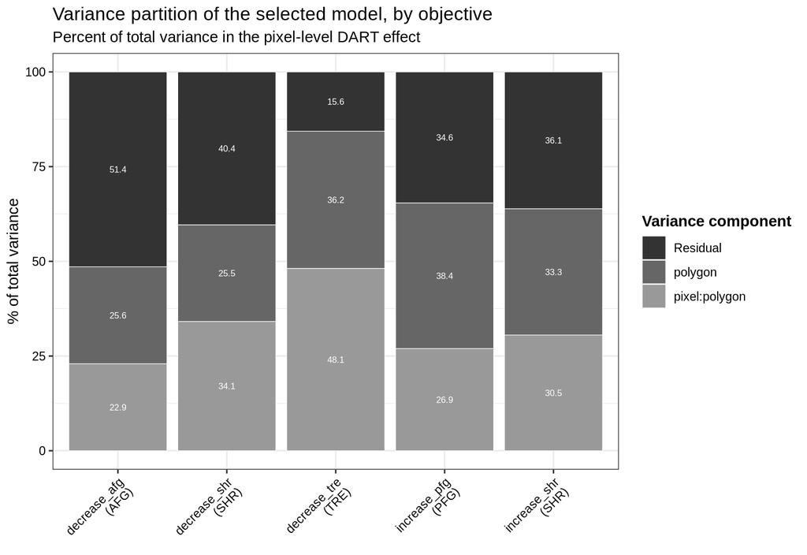

**Figure.** Percent of total variance in the pixel-level DART effect (y axis) by objective x cover response (x axis), with fill giving the variance component - the polygon random intercept, the pixel-within-polygon random intercept, and the residual. Bars sum to 100% within each objective. Printed labels are omitted from segments below 6% of the bar, which cannot hold readable text. Each bar comes from that objective’s own selected model, so the models behind two bars may carry different fixed effects.

Variance components of each objective’s selected model, in the squared units of the response. These are maximum-likelihood estimates: refit the selected model with REML = TRUE before quoting a variance component on its own.

| Objective | Cover | Model | Component | Variance | SD | % of Variance |
| --- | --- | --- | --- | --- | --- | --- |
| decrease_afg | AFG | m6 | pixel:polygon | 31.901 | 5.648 | 22.93 |
| decrease_afg | AFG | m6 | polygon | 35.656 | 5.971 | 25.63 |
| decrease_afg | AFG | m6 | Residual | 71.577 | 8.460 | 51.44 |
| increase_pfg | PFG | m6 | pixel:polygon | 18.017 | 4.245 | 26.95 |
| increase_pfg | PFG | m6 | polygon | 25.698 | 5.069 | 38.44 |
| increase_pfg | PFG | m6 | Residual | 23.136 | 4.810 | 34.61 |
| increase_shr | SHR | m6 | pixel:polygon | 13.089 | 3.618 | 30.54 |
| increase_shr | SHR | m6 | polygon | 14.283 | 3.779 | 33.32 |
| increase_shr | SHR | m6 | Residual | 15.492 | 3.936 | 36.14 |
| decrease_shr | SHR | m6 | pixel:polygon | 21.642 | 4.652 | 34.13 |
| decrease_shr | SHR | m6 | polygon | 16.157 | 4.020 | 25.48 |
| decrease_shr | SHR | m6 | Residual | 25.607 | 5.060 | 40.39 |
| decrease_tre | TRE | m6 | pixel:polygon | 49.339 | 7.024 | 48.11 |
| decrease_tre | TRE | m6 | polygon | 37.178 | 6.097 | 36.25 |
| decrease_tre | TRE | m6 | Residual | 16.045 | 4.006 | 15.64 |

## Fixed effects

Estimates are in the response’s own units - the differenced RAP cover effect - except for `aridity`, `spei` and `mean_cover_5YBT`, which were centred and scaled, so their coefficients are the change per standard deviation. `year_diff` was left in years, so its coefficient reads directly as change per year since treatment.

The intercept is dropped from the figure because its scale swamps the contrasts; it is in the table. Treatment and ecoregion terms are contrasts against whichever level sorted first, not effects of that level in isolation.

Intervals are the model’s own, computed by the **Wald** method. lme4 offers three — the Wald quadratic approximation, likelihood profiling, and a parametric bootstrap — and on the package authors’ own worked example the three agreed closely, the largest discrepancy being about a quarter of the interval width and falling on a random-effect correlation rather than a fixed effect. Wald is the only one affordable at this sample size: profiling and bootstrapping both refit the model many times over hundreds of thousands of rows. It is worth running `profile` once on the smallest objective to confirm the Wald intervals reported here are trustworthy, since the Wald approximation is exactly the one that degrades when a likelihood profile is non-linear.

[figure not shown]

Fixed effects of each objective’s selected model. `Intended Sign` is -1 where the management goal was a decrease in cover and +1 where it was an increase, from get_intended_sign(); it is the objective’s goal, not a property of the term. `t Value` is carried as a magnitude, not a test statistic - no p values are reported here, and the likelihood ratio tests above are where an inferential statement should be read from instead.

| Objective | Cover | Model | Term | Estimate | SE | CI Lower | CI Upper | CI Method | t Value | Intended Sign |
| --- | --- | --- | --- | --- | --- | --- | --- | --- | --- | --- |
| decrease_afg | AFG | m6 | (Intercept) | -1.9464 | 4.3597 | -10.4913 | 6.5985 | Wald | -0.446 | -1 |
| decrease_afg | AFG | m6 | year_diff | 0.0487 | 0.0059 | 0.0373 | 0.0602 | Wald | 8.320 | -1 |
| decrease_afg | AFG | m6 | tx_coarseseeding;soil disturbance | 1.0049 | 2.0359 | -2.9854 | 4.9953 | Wald | 0.494 | -1 |
| decrease_afg | AFG | m6 | tx_coarseseeding;soil disturbance;vegetation removal | 2.0030 | 2.1756 | -2.2611 | 6.2671 | Wald | 0.921 | -1 |
| decrease_afg | AFG | m6 | tx_coarseseeding;vegetation removal | -0.9587 | 1.9543 | -4.7889 | 2.8716 | Wald | -0.491 | -1 |
| decrease_afg | AFG | m6 | tx_coarsesoil disturbance;vegetation removal | 3.4839 | 4.5345 | -5.4036 | 12.3714 | Wald | 0.768 | -1 |
| decrease_afg | AFG | m6 | tx_coarsevegetation removal | -3.3640 | 2.0816 | -7.4438 | 0.7158 | Wald | -1.616 | -1 |
| decrease_afg | AFG | m6 | aridity | -0.3316 | 0.0444 | -0.4187 | -0.2445 | Wald | -7.463 | -1 |
| decrease_afg | AFG | m6 | spei | 0.3601 | 0.0346 | 0.2922 | 0.4281 | Wald | 10.394 | -1 |
| decrease_afg | AFG | m6 | us_l4nameEscarpments | 5.5691 | 4.9731 | -4.1779 | 15.3161 | Wald | 1.120 | -1 |
| decrease_afg | AFG | m6 | us_l4nameFoothill Shrublands and Low Mountains | -0.5142 | 7.4457 | -15.1076 | 14.0791 | Wald | -0.069 | -1 |
| decrease_afg | AFG | m6 | us_l4nameMonticello-Cortez Uplands | 7.5070 | 7.4579 | -7.1103 | 22.1243 | Wald | 1.007 | -1 |
| decrease_afg | AFG | m6 | us_l4nameMountain Valleys | 6.4108 | 5.9561 | -5.2629 | 18.0845 | Wald | 1.076 | -1 |
| decrease_afg | AFG | m6 | us_l4nameNorthern Uinta Basin Slopes | 7.7435 | 7.4235 | -6.8063 | 22.2933 | Wald | 1.043 | -1 |
| decrease_afg | AFG | m6 | us_l4nameRolling Sagebrush Steppe | 5.0756 | 7.6667 | -9.9509 | 20.1022 | Wald | 0.662 | -1 |
| decrease_afg | AFG | m6 | us_l4nameSagebrush Basins and Slopes | 5.8952 | 4.4661 | -2.8583 | 14.6487 | Wald | 1.320 | -1 |
| decrease_afg | AFG | m6 | us_l4nameSemiarid Benchlands and Canyonlands | 0.2877 | 4.7041 | -8.9321 | 9.5076 | Wald | 0.061 | -1 |
| decrease_afg | AFG | m6 | us_l4nameSemiarid Foothills | 5.4780 | 4.8219 | -3.9727 | 14.9288 | Wald | 1.136 | -1 |
| decrease_afg | AFG | m6 | us_l4nameSemiarid Hills and Low Mountains | 7.0801 | 6.0143 | -4.7077 | 18.8678 | Wald | 1.177 | -1 |
| decrease_afg | AFG | m6 | us_l4nameShadscale-Dominated Saline Basins | 2.1953 | 5.1213 | -7.8423 | 12.2328 | Wald | 0.429 | -1 |
| decrease_afg | AFG | m6 | us_l4nameUinta Basin Floor | -5.6424 | 7.6469 | -20.6300 | 9.3452 | Wald | -0.738 | -1 |
| decrease_afg | AFG | m6 | us_l4nameWoodland- and Shrub-Covered Low Mountains | 6.8431 | 4.4837 | -1.9447 | 15.6309 | Wald | 1.526 | -1 |
| decrease_afg | AFG | m6 | mean_cover_5YBT | -4.4421 | 0.1444 | -4.7251 | -4.1591 | Wald | -30.762 | -1 |
| increase_pfg | PFG | m6 | (Intercept) | 0.9334 | 3.9234 | -6.7563 | 8.6230 | Wald | 0.238 | 1 |
| increase_pfg | PFG | m6 | year_diff | -0.0376 | 0.0011 | -0.0397 | -0.0355 | Wald | -34.808 | 1 |
| increase_pfg | PFG | m6 | tx_coarseprescribed burn;seeding | 1.1713 | 2.5584 | -3.8430 | 6.1857 | Wald | 0.458 | 1 |
| increase_pfg | PFG | m6 | tx_coarseprescribed burn;seeding;soil disturbance;vegetation removal | 1.2711 | 3.3128 | -5.2219 | 7.7641 | Wald | 0.384 | 1 |
| increase_pfg | PFG | m6 | tx_coarseprescribed burn;soil disturbance | 6.4620 | 5.3331 | -3.9906 | 16.9146 | Wald | 1.212 | 1 |
| increase_pfg | PFG | m6 | tx_coarseprescribed burn;vegetation removal | 5.0400 | 2.9854 | -0.8113 | 10.8912 | Wald | 1.688 | 1 |
| increase_pfg | PFG | m6 | tx_coarseseeding | 2.7022 | 1.5473 | -0.3305 | 5.7348 | Wald | 1.746 | 1 |

[output cut: 117 more lines]

For orientation while reading that table, each objective’s goal in words:

The raw sign of the cover effect each objective was aiming for, from intended_dir_word().

| Objective | Cover | Intended |
| --- | --- | --- |
| decrease_afg | AFG | negative |
| increase_pfg | PFG | positive |
| increase_shr | SHR | positive |
| decrease_shr | SHR | negative |
| decrease_tre | TRE | negative |

## Posterior predictive check

A different question from the residual plots: rather than asking whether the errors look as assumed, this asks whether data simulated *from the fitted model* looks like the data that was observed. Each selected model was used to simulate 200 datasets; a summary statistic was computed on each, and the observed statistic located in that distribution.

Two statistics, because they fail differently. The **IQR** is the spread of the bulk of the distribution. The **SD** is dominated by the tails. A model that reproduces the IQR but badly under-predicts the SD is getting the typical pixel right and the extreme ones wrong — which is the failure to expect here, since the response is itself an estimate whose own error grows where cover is low.

`p` is one-tailed and counts the observed value into its own reference distribution, so it can never be exactly 0 or 1. Values near 0.5 are unremarkable; values near either end are the signal. One caveat carried over from the method itself: unlike a full Bayesian check this conditions on the fitted parameters and ignores their uncertainty, which is a reasonable approximation when the residual variation is large — as it is here.

Posterior predictive check on each objective’s selected model. `Observed` is the statistic computed on the fitted response; the three simulated columns summarise the same statistic across simulated datasets.

| Objective | Cover | Model | Statistic | Observed | Simulated Mean | Sim. 2.5% | Sim. 97.5% | # Simulations | p |
| --- | --- | --- | --- | --- | --- | --- | --- | --- | --- |
| decrease_afg | AFG | m6 | IQR | 9.3439 | 17.4717 | 16.0767 | 19.3237 | 200 | 0.0050 |
| decrease_afg | AFG | m6 | sd | 11.9810 | 12.8937 | 11.9257 | 14.1311 | 200 | 0.0498 |
| increase_pfg | PFG | m6 | IQR | 9.0208 | 11.7990 | 10.9408 | 13.5689 | 200 | 0.0050 |
| increase_pfg | PFG | m6 | sd | 8.1426 | 8.7677 | 8.2244 | 9.7820 | 200 | 0.0149 |
| increase_shr | SHR | m6 | IQR | 7.5331 | 10.1911 | 9.5267 | 11.2257 | 200 | 0.0050 |
| increase_shr | SHR | m6 | sd | 7.1738 | 7.6208 | 7.2021 | 8.3372 | 200 | 0.0299 |
| decrease_shr | SHR | m6 | IQR | 8.1069 | 11.5062 | 10.6620 | 13.3287 | 200 | 0.0050 |
| decrease_shr | SHR | m6 | sd | 8.0252 | 8.5585 | 7.9187 | 9.7794 | 200 | 0.0945 |
| decrease_tre | TRE | m6 | IQR | 10.5134 | 15.4676 | 14.2867 | 17.5743 | 200 | 0.0050 |
| decrease_tre | TRE | m6 | sd | 11.2407 | 11.3997 | 10.6718 | 12.6776 | 200 | 0.4229 |

## Fit diagnostics

Four figures per objective, all from its selected model. The first three are drawn on one common subsample of residuals, so they cannot disagree about which residuals they show.

**Residual against fitted** is the general-purpose plot. **Scale-location** — the square root of the absolute residual against the fitted value, with a loess trend — is where heteroscedasticity shows most directly, and that is the assumption most at risk: a pixel-level DART effect is an estimate with its own standard error, and that error is not constant across the range of cover the pixels span. A trend that rises with the fitted value says the model’s single residual variance is describing two different things. The **residual Q-Q** is where heavy tails show, and heavy tails are what would make every interval in the table above optimistic.

The fourth asks a question the other three cannot. **The random-effect Q-Q** plots the conditional modes of the polygon and pixel intercepts. The residual plots test the within-pixel errors; this tests whether the polygon and pixel intercepts are themselves normal, which is a separate assumption the model makes and one nothing else in this project looks at.

**Nothing here is tested.** These are drawn for inspection; no result in this document is conditioned on them and no assumption has been assessed. In a `sigonly` run the residuals are bimodal by construction, because the sample is selected on the outcome and its two tails are selected in opposite directions — that is an expected feature of that run, not a fixable misfit.

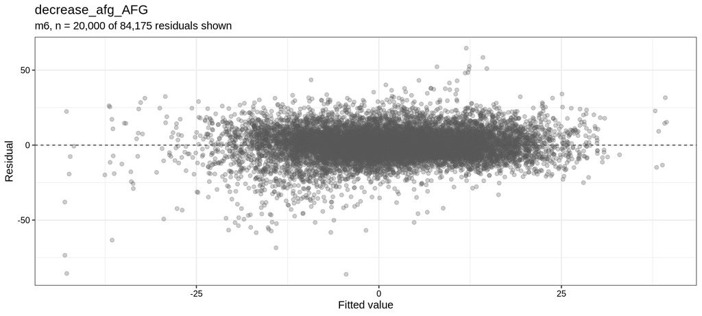

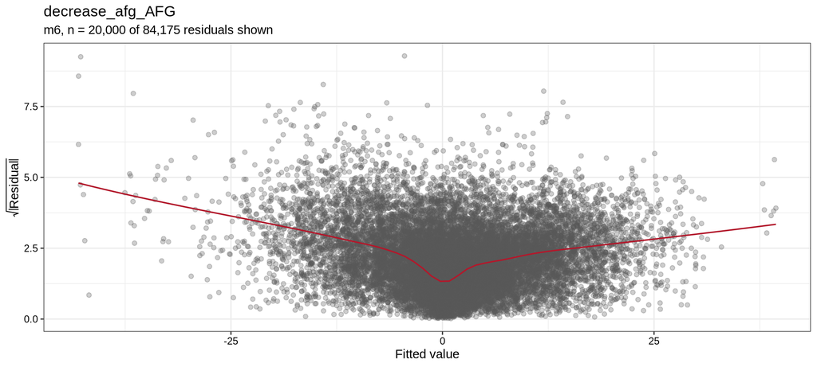

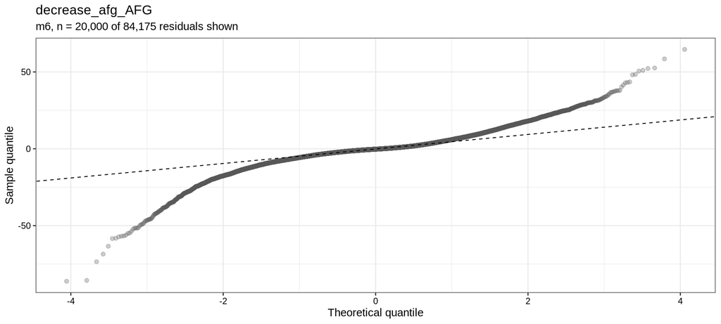

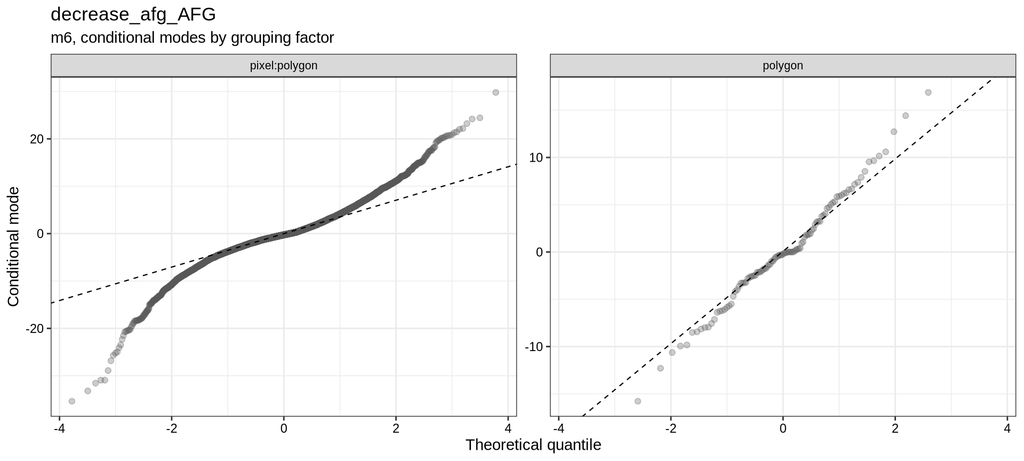

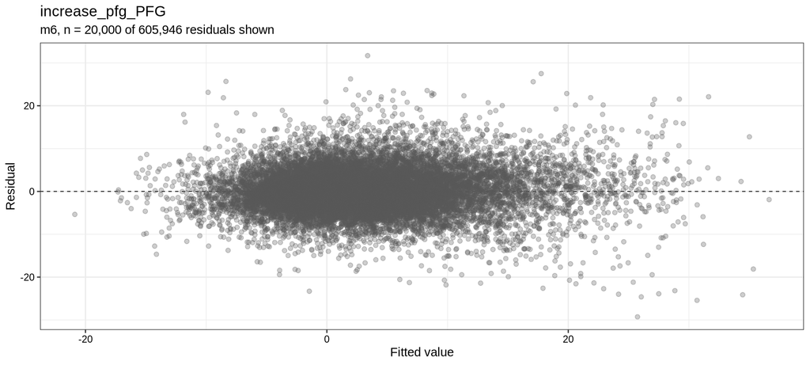

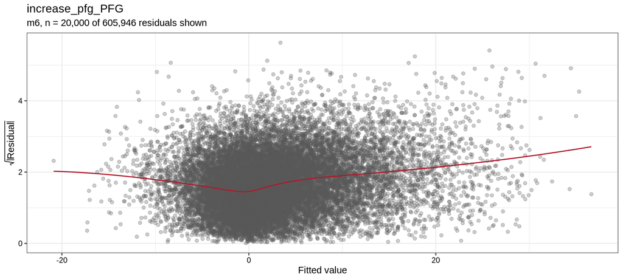

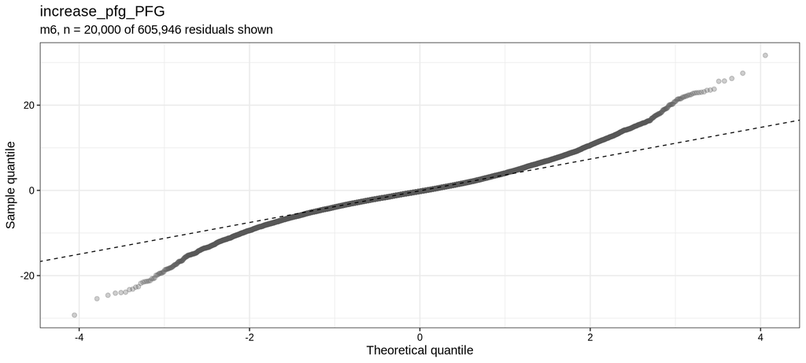

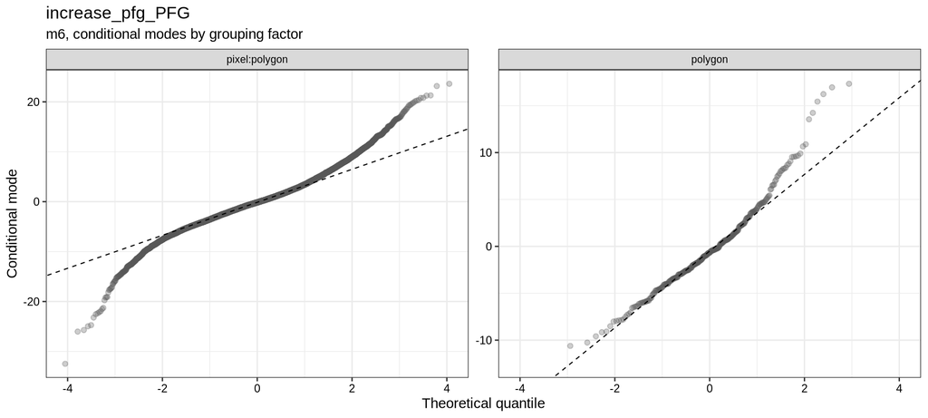

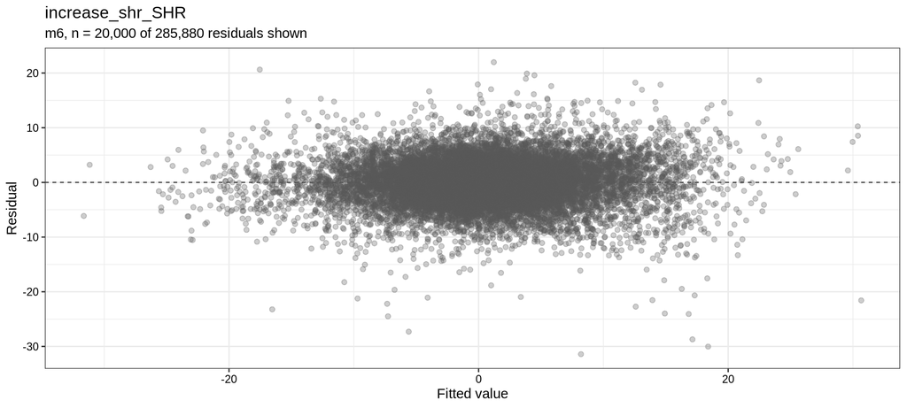

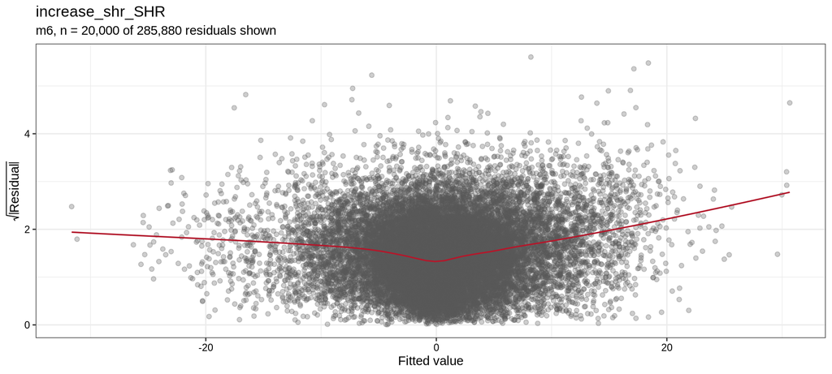

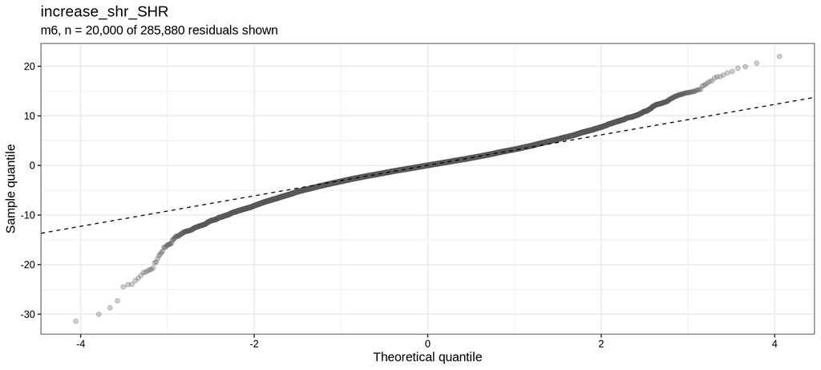

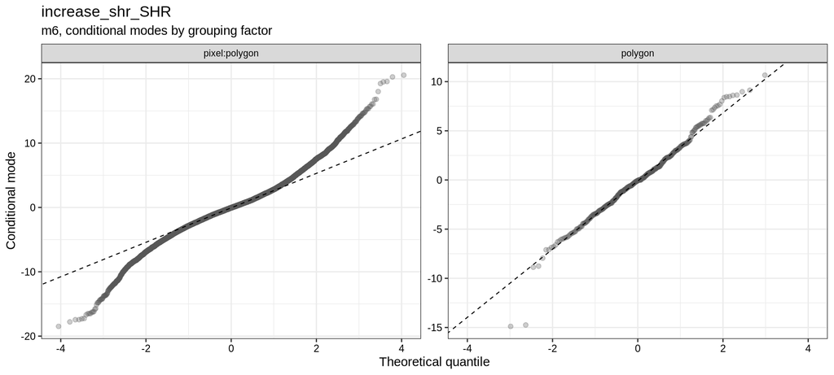

[8 more figures not shown]

**Figure.** For each objective in turn, four panels: residual against fitted value; scale-location, the square root of the absolute residual against the fitted value with a loess trend in red; the normal Q-Q plot of those same residuals; and the normal Q-Q plot of the random-effect conditional modes, facetted by grouping factor. Every panel title names the objective x cover response, and the subtitle names the selected model and how many points are drawn out of how many rows were fit — the figures are subsampled because a saved plot object carries its own data, and plotting every residual would make the `.Rdata` slower to load than the models are to refit. Dashed lines are zero in the first panel and the first-and-third-quartile reference line in both Q-Q panels.

## Caveats

The two standing caveats from the results report apply unchanged, because these models are fit to the same rows:

- Objective groupings are **not a partition** - a pixel counts toward an objective if it fell in any part of that objective, so multi-objective treatments appear in several groupings and parts of the dataset are counted more than once.
- An objective/response pairing is only included when the response cover type matches the objective’s target cover, with **bare ground the sole exception** (shown against all objectives).

Five more belong to this stage specifically:

- **The models are unweighted.** The DART stage gives every pixel a confidence interval, and `1 / (upper - lower)` would be the obvious precision weight, but BEM settled on no weighting after the simulation in `weight_testing_summary.Rmd` and that decision is carried forward here rather than reopened.
- **The five objectives were filtered at different thresholds** (default=10; decrease_afg_AFG=300; increase_pfg_PFG=300; increase_shr_SHR=300; decrease_shr_SHR=300), so their coefficients are not straightforwardly comparable with each other. The filtering log in `2_make_DART_results.Rmd` records what each threshold cost.
- **One model per objective, never one across objectives.** A pooled intercept over a `decrease_*` and an `increase_*` objective would average opposite intended signs.
- **No spatial or temporal autocorrelation term.** Pixels inside a polygon are close together and observed in consecutive years, and nothing in these models accounts for that beyond the polygon and pixel random intercepts. This is the most likely reason a fixed effect above looks more precise than it is, and it is unfinished business carried over from KY’s original scripts, which close on `ape::Moran.I` and `stats::acf`.
- **`us_l4name` enters as a fixed effect while `polygon` is a random intercept.** Every polygon sits in exactly one ecoregion, so the two are nested rather than crossed, and whether ecoregion belongs as a fixed effect, as a third random grouping, or as the level at which treatment effects are allowed to vary is an open question rather than a settled choice.